title: “Model Comparison: Implementation” author: “Steve Buyske” output: html_document

## Working example

- We will look again at the Citibike usage in 2020.
- This time, though, I’ve expanded the data from May 1 to August 31, and included variables for the average number of Covid-19 cases in the city over the previous 7 days, for the high temperature, and for the daily rainfall.
  - After looking at the data, I defined a new variable, `lrainfall = log(rainfall + 1)`.
- A plot of rides temperature seems to suggest including a quadratic term for temperature.

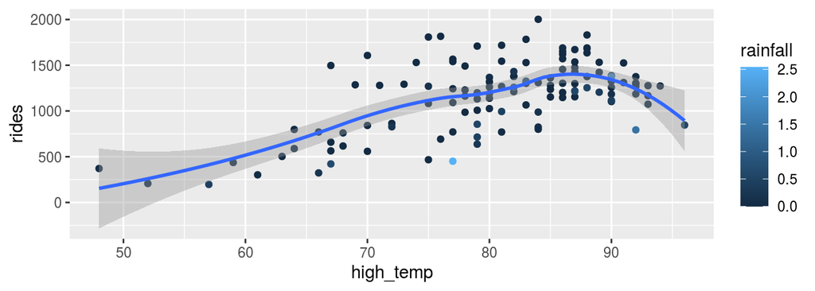

```r
citibike3 %>%
  filter(year == "2020") %>%
  ggplot(aes(high_temp, rides, colour = rainfall)) +
  geom_point() +
  geom_smooth()
```

## First question: group terms

- Let’s start with four models, each with different groupings for group-level intercepts.

```r
set.seed(2020)

citibike3_fit1a <-
  stan_glmer(
    rides ~ high_temp + I(high_temp^2) + lrainfall + covid_cases +
      (1 | day_of_the_week) + (1 | week_of_the_year),
    data = citibike3 %>% filter(year == "2020"),
    adapt_delta = 0.999,
    chains = 8,
    prior_covariance = decov(2)
  )

citibike3_fit1b <-
  stan_glmer(
    rides ~ high_temp + I(high_temp^2) + lrainfall + covid_cases +
      (1 | week_of_the_year),
    data = citibike3 %>% filter(year == "2020"),
    adapt_delta = 0.999,
    chains = 8,
    prior_covariance = decov(2)
  )



citibike3_fit1c <-
  stan_glmer(
    rides ~ high_temp + I(high_temp^2) + lrainfall + covid_cases +
      (1 | day_of_the_week),
    data = citibike3 %>% filter(year == "2020"),
    adapt_delta = 0.999,
    chains = 8,
    prior_covariance = decov(2)
  )

citibike3_fit1d <-
  stan_glm(
    rides ~ high_temp + I(high_temp^2) + lrainfall + covid_cases,
    data = citibike3 %>% filter(year == "2020"),
    adapt_delta = 0.999,
    chains = 8
  )
```

## The `loo()` function

- The `loo()` function will calculate the PSIS LOO-CV estimate of elppd, and will warn if there is a problem.

```r
citi_loo_1a <- loo(citibike3_fit1a)
```

```
## Warning: Found 2 observation(s) with a pareto_k > 0.7. We recommend calling 'loo' again with argument 'k_threshold = 0.7' in order to calculate the ELPD without the assumption that these observations are negligible. This will refit the model 2 times to compute the ELPDs for the problematic observ…
```

- You can address the warning by adding the `k_threshold = 0.7` argument; the function will use actual loo-cv for the troublesome observations.

```r
citi_loo_1a <- loo(citibike3_fit1a, k_threshold = 0.7)
```

```
## 2 problematic observation(s) found.
## Model will be refit 2 times.
```

```
##
## Fitting model 1 out of 2 (leaving out observation 104)
```

```
##
## Fitting model 2 out of 2 (leaving out observation 108)
```

(Notice how much longer this takes than when you don’t need the `k_threshold` argument.)

```r
citi_loo_1b <-   loo(citibike3_fit1b, k_threshold = 0.7)
```

```
## 1 problematic observation(s) found.
## Model will be refit 1 times.
```

```
##
## Fitting model 1 out of 1 (leaving out observation 104)
```

```r
citi_loo_1c <-   loo(citibike3_fit1c)
citi_loo_1d <-   loo(citibike3_fit1d)
```

- We use `loo_compare()` to compare the estimated elppd’s

```r
loo_compare(citi_loo_1a,
            citi_loo_1b,
            citi_loo_1c,
            citi_loo_1d)
```

```
##                 elpd_diff se_diff
## citibike3_fit1c   0.0       0.0
## citibike3_fit1a  -1.0       1.2
## citibike3_fit1d -31.6       8.0
## citibike3_fit1b -32.4       8.0
```

- The `elpd_diff` shows the differences in the estimate elppd from the best model on the top row, while `se_diff` shows an estimate standard error for that difference.

## First decision

```r
loo_compare(citi_loo_1a,
            citi_loo_1b,
            citi_loo_1c,
            citi_loo_1d)
```

```
##                 elpd_diff se_diff
## citibike3_fit1c   0.0       0.0
## citibike3_fit1a  -1.0       1.2
## citibike3_fit1d -31.6       8.0
## citibike3_fit1b -32.4       8.0
```

- It looks like `citibike3_fit1c` is really much better than models 1b and 1d, but comparable to model 1a. Since 1c is a bit simpler, we will stick with that.

## Second choice: covariates

- Next let’s try models with different population-level covariates.

```r
citibike3_fit2 <- stan_glmer(rides ~ high_temp + I(high_temp^2) + lrainfall + (1 | day_of_the_week),
                             data = citibike3 %>% filter(year == "2020"), adapt_delta = 0.999,
                             chains = 8, prior_covariance = decov(2))

citibike3_fit3 <- stan_glmer(rides ~ lrainfall + (1 | day_of_the_week),
                             data = citibike3 %>% filter(year == "2020"), adapt_delta = 0.999,
                             chains = 8, prior_covariance = decov(2))

citibike3_fit4 <- stan_glmer(rides ~ high_temp + I(high_temp^2)  + (1 | day_of_the_week),
                             data = citibike3 %>% filter(year == "2020"), adapt_delta = 0.999,
                             chains = 8, prior_covariance = decov(2))

citibike3_fit5 <- stan_glmer(rides ~ high_temp + I(high_temp^2) * lrainfall + (1 | day_of_the_week),
                             data = citibike3 %>% filter(year == "2020"), adapt_delta = 0.999,
                             chains = 8, prior_covariance = decov(2))
```

```r
citi_loo_2 <- loo(citibike3_fit2)
citi_loo_3 <- loo(citibike3_fit3)
citi_loo_4 <- loo(citibike3_fit4)
citi_loo_5 <- loo(citibike3_fit5)
```

- How do they compare?

```r
loo_compare(
  citi_loo_1c,
  citi_loo_2,
  citi_loo_3,
  citi_loo_4,
  citi_loo_5
)
```

```
##                 elpd_diff se_diff
## citibike3_fit1c   0.0       0.0
## citibike3_fit5  -10.7       6.7
## citibike3_fit2  -11.9       5.3
## citibike3_fit4  -20.0       7.8
## citibike3_fit3  -63.8      10.9
```

- It looks like `citibike3_fit1c`, `citibike3_fit2`, and `citibike3_fit5` are all worth considering.

## Big models

- Since `citibike3_fit1c` has all the covariates and is readily interpretable, let’s take a final look at that.

```r
describe_posterior(citibike3_fit1c, centrality = "mean", ci = 0.9, rope_ci = 0.9)
```

```
## # Description of Posterior Distributions
##
## Parameter      |      Mean |                 90% CI |      pd |          90% ROPE | % in ROPE |  Rhat |      ESS
## ----------------------------------------------------------------------------------------------------------------
## (Intercept)    | -3420.626 | [-4935.982, -1987.226] | 100.00% | [-38.549, 38.549] |         0 | 1.001 | 4216.464
## high_temp      |   111.012 | [   74.133,   149.088] | 100.00% | [-38.549, 38.549] |         0 | 1.001 | 4288.042
## I(high_temp^2) |    -0.629 | [   -0.872,    -0.388] | 100.00% | [-38.549, 38.549] |       100 | 1.001 | 4335.292
## lrainfall      |  -495.594 | [ -644.688,  -345.449] | 100.00% | [-38.549, 38.549] |         0 | 1.000 | 7455.442
## covid_cases    |    -0.344 | [   -0.451,    -0.234] | 100.00% | [-38.549, 38.549] |       100 | 1.000 | 6616.621
```

- It looks like `high_temp`, `lrainfall`, and `covid_cases` all have non-negligible effects.
- Keep in mind, though, that the scales are different.

```r
citibike3 %>%
  filter(year == "2020") %>%
  select(high_temp, lrainfall, covid_cases) %>%
  summarize_all(quantile, prob = c(0.25, 0.75))
```

```
## # A tibble: 2 x 3
##   high_temp lrainfall covid_cases
##       <dbl>     <dbl>       <dbl>
## 1      76.5    0             254
## 2      87      0.0535        606.
```

```r
describe_posterior(citibike3_fit1c, centrality = "mean", ci = 0.9, rope_ci = 0.9, effect = "random")
```

```
## # Description of Posterior Distributions
##
## Parameter                                      |      Mean |                90% CI |      pd |          90% ROPE | % in ROPE |  Rhat |      ESS
## -----------------------------------------------------------------------------------------------------------------------------------------------
## day_of_the_week:Sun                            |   202.958 | [  55.605,   355.878] |  98.59% | [-38.549, 38.549] |     0.000 | 1.002 | 2349.797
## day_of_the_week:Mon                            |  -132.523 | [-275.336,    20.151] |  93.47% | [-38.549, 38.549] |    11.526 | 1.003 | 2325.322
## day_of_the_week:Tue                            |  -105.422 | [-255.158,    46.164] |  88.45% | [-38.549, 38.549] |    18.720 | 1.002 | 2442.087
## day_of_the_week:Wed                            |   -53.974 | [-201.400,    98.806] |  73.89% | [-38.549, 38.549] |    31.398 | 1.003 | 2317.742
## day_of_the_week:Thu                            |  -130.089 | [-282.389,    21.907] |  92.77% | [-38.549, 38.549] |    10.887 | 1.002 | 2462.864
## day_of_the_week:Fri                            |  -101.406 | [-250.307,    50.281] |  87.39% | [-38.549, 38.549] |    19.442 | 1.002 | 2410.153
## day_of_the_week:Sat                            |   300.524 | [ 156.142,   454.528] |  99.88% | [-38.549, 38.549] |     0.000 | 1.003 | 2396.112
## Sigma[day_of_the_week:(Intercept),(Intercept)] | 46762.516 | [9296.033, 87554.547] | 100.00% | [-38.549, 38.549] |     0.000 | 1.005 | 2334.098
```

## Bayes factors

- Let’s take a look at a comparison of `citibike3_fit1c`, `citibike3_fit2`, and `citibike3_fit5` using Bayes factors.
- We will stick with weakly informative priors, partly out of laziness and partly because I don’t have a reason to have informative priors.
- Just remember that I don’t recommend Bayes factors unless you do have informative priors.
- First, we have to refit the models to include the extra file. Note the larger value of iterations as well, so that there are 40,000 samples after warmup.

```r
citibike3_fit1c_bf <-
  stan_glmer(
    rides ~ high_temp + I(high_temp ^ 2) + lrainfall + covid_cases +
      (1 | day_of_the_week),
    data = citibike3 %>% filter(year == "2020"),
    adapt_delta = 0.999,
    chains = 8,
    prior_covariance = decov(2),
    diagnostic_file = file.path(tempdir(), "df1c.csv"),
    iter = 10000
  )

citibike3_fit2_bf <-
  stan_glmer(
    rides ~ high_temp + I(high_temp ^ 2) + lrainfall + (1 |  day_of_the_week),
    data = citibike3 %>% filter(year == "2020"),
    adapt_delta = 0.999,
    chains = 8,
    prior_covariance = decov(2),
    diagnostic_file = file.path(tempdir(), "df2.csv"),
    iter = 10000
  )



citibike3_fit5_bf <-
  stan_glmer(
    rides ~ high_temp + I(high_temp ^ 2) * lrainfall + (1 | day_of_the_week),
    data = citibike3 %>% filter(year == "2020"),
    adapt_delta = 0.999,
    chains = 8,
    prior_covariance = decov(2),
    diagnostic_file = file.path(tempdir(), "df5.csv"),
    iter = 10000
  )
```

```r
bayesfactor_models(citibike3_fit2_bf, citibike3_fit1c_bf)
```

```
## Computation of Bayes factors: estimating marginal likelihood, please wait...
```

```
## # Bayes Factors for Model Comparison
##
##   Model
##   [2] high_temp + I(high_temp^2) + lrainfall + covid_cases + (1 | day_of_the_week)
##         BF
##  11198.696
##
## * Against Denominator: [1] high_temp + I(high_temp^2) + lrainfall + (1 | day_of_the_week)
## *   Bayes Factor Type: marginal likelihoods (bridgesampling)
```

```r
bayesfactor_models(citibike3_fit5_bf, citibike3_fit1c_bf)
```

```
## Computation of Bayes factors: estimating marginal likelihood, please wait...
```

```
## # Bayes Factors for Model Comparison
##
##   Model
##   [2] high_temp + I(high_temp^2) + lrainfall + covid_cases + (1 | day_of_the_week)
##         BF
##  12375.111
##
## * Against Denominator: [1] high_temp + I(high_temp^2) * lrainfall + (1 | day_of_the_week)
## *   Bayes Factor Type: marginal likelihoods (bridgesampling)
```